# Complexity in Landscape Ecology by Green et al.

Joseph Lewis

24 August 2020

# Chapter One: Complexity and Ecology

Complexity is the richness and variety often seen in large systems. Species diversity is often used to represent complexity in ecosystems, but true complexity arises from the enormous number of ways to order combinations of objects.

simple assumptions about ecological systems can lead to disastrous mistakes in land management. Almost always, problems arise because the complexity of landscapes and ecosystems defeats our efforts to understand them as simple systems of cause and effect.

The underlying error in this ongoing catastrophe is “cause and effect” thinking: assuming that the forest ecosystem is a direct effect of suitable climate and soil conditions, rather than a complex, dynamic process in itself.

When people first began using computer models to study ecosystems, spatial interactions were largely ignored. Local interactions between individuals were assumed to be minor effects that would average out over time and space. Unfortunately, the assumption that local effects will average out over time and space is incorrect.

Interactions do matter, and local interactions can blow up to have large-scale effects. In ecological systems, many of these interactions are not simple, one-way cause and effect relationships, but complex feedback relationships

## What is Complexity?

### Variety and Form:

Complex systems, however, are often unpredictable, rich in interactions, and large-scale properties of behaviour often emerges from those interactions.

## What Makes Ecosystems Complex?

### Measuring Diversity:

In landscape ecology, as in every area of science, there is a close relationship between theory and data. The theories that scientists develop are limited by the data available to them. Conversely, the data that scientists collect are determined by the theories that they wish to test and by the experiments, or observations that they carry out.

complexity really comprises two component strings: primary order (or ordered complexity), which is the set of rules describing pattern in a system, and secondary order, which describes the entropy, or random components.

Real complexity stems from the enormous variety of ways in which species combine and interact. Interactions between pairs of species can take many forms, such as predation, parasitism and competition.

Given the richness of ecological interactions, we cannot hope for a simple and general understanding of the behaviour of ecosystems. However, We can view ecological interactions as a network of connections, recognising that although complex systems are diverse, they also tend to share certain internal structures and processes that lead to consistent behaviours.

If patterns in space are important, then so too are patterns in time. Apparently random events, such as drought, flood and fire, each cause massive and unpredictable mortality, but also provide opportunities. Both the frequency and magnitude of environmental variations can strongly influence ecological structures.

Understanding the interaction between feedback processes and temporal and spatial variation within ecosystems has helped to resolve some key questions that cannot easily be approached empirically.

Simulation models in which sets of interacting populations are formed randomly predicted that systems with greater numbers of species are more likely to collapse, simply because there is a greater chance of forming positive feedback loops. Stability permits complexity.

## Complexity Paradigm

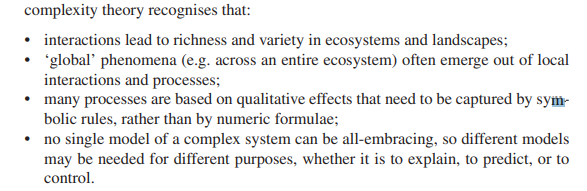

simulation is a tool that scientists can use to represent patterns and processes in nature. The difference is that equations are solved, whereas simulations are played out. Because complex systems are often inherently unpredictable, we examine scenarios instead of making forecasts. Instead of solving equations, we perform sensitivity analyses.

*A new Ecology for a New Age*

Learning what happens when you put things back together is what complexity research is all about.

# Chapter Two: Emergent Order in Growth and Behaviour

The patterns we see in the growth of a plant or the behaviour of animals can appear very complex, but there are often simple rules that underlie what we see. Simple rules of behaviour can explain many features of animal behaviour; multi-agent simulations use these rules to model community organisation and interaction with the environment.

If you are trying to understand the workings of a flock of birds, or of a forest ecosystem, then you can only get so far by studying more and more about the individuals. The way that living creatures interact, the properties that allow one plant to outgrow another, the relative speed of predator and prey are all characteristics that count on a larger scale.

self-organisation works, how a large number of individuals become organised into an ecosystem, a certain amount of abstraction is needed. Traditional models tend to gloss over processes that involve interactions at the level of local individuals or elements. Instead they tend to look either at the large scale, or else at the fine details. They tend to take a top-down view of how constraints act on individuals, rather than a bottom-up view of the effects that arise from interactions between individuals.

Three important features of plant structural development are modularity, iteration and recursion.

Modularity is important because we can model growth and development in terms of repeating components without needing to consider cellular or other lower levels of biological organisation

iteration we mean that the same processes repeat over and over.

recursion or self-similarity we mean that developmental patterns can recur at increasingly lower levels (patterns repeated within patterns).

## Animal Behaviour

Some of the great challenges of ecology are to identify processes that govern the ways animals behave and to understand the effects that arise from their interactions with each other and with their environment. Many aspects of animal behaviour arise from the need to survive in a complex environment.

A common finding in agent models is that the behaviour of a large-scale system emerges from the properties and interactions of many individual agents. intricate forms of order can emerge from relatively simple interactions between organisms with each other and with their environment. Global organisation is simply a by-product of local interactions.

# Chapter Three: Complexity in Landscapes

Complexity often arises in the way things are distributed in a landscape. Sampling is subject to scale and can display properties of fractals. Cellular automata, which represent a landscape as a grid of sites, are often used to model processes in landscapes. These models highlight the phase change that occurs between connected and fragmented landscapes.

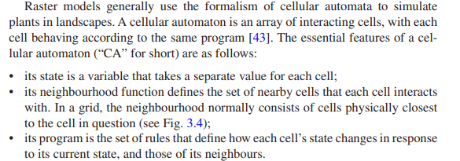

The most important feature of the CA model is the role of the neighbourhood. Any cell, taken in isolation, behaves in a certain simple way, just like a tree that grows by itself in a glasshouse. However, just as trees in a forest interact with each other to produce a rich variety of growth, form and dynamics, so it is the interactions of each cell with its neighbours that dominate the behaviour of a cellular automaton model.

regularities in the model tend to produce order. Starting from an arbitrary initial configuration, order usually emerges fairly quickly in the model. This order takes the form of areas with welldefined patterns. Ultimately most configurations either disappear entirely or break up into isolated patterns. These patterns are either static or else cycle between several different forms with a fixed period.

Ecologists have applied cellular automata models to many problems in landscape ecology. One common application has been to identify the way in which particular kinds of spatial patterns form. For example, a team of scientists used CA models to look at the vegetation patterns that resulted from the combination of tree growth rates and the killing capacity of the wind in the subantarctic forest of Tierra del Fuego. They were able to show that simulated patterns for heterogeneous forests with random age distributions matched the patterns observed in nature

## Sampling and Scale

In landscapes, the patterns that we see are reflections of the processes that produced them. The distributions of plants and animals arise from a multitude of processes that we have to tease apart.

The essential problem of landscape complexity is that as often as not, complex processes leave behind complex patterns. To interpret a complex pattern often requires a lot of data.

## Complexity in Spatial Processes

Spatial processes are inherently complex. In almost every case, spatial processes involve interactions between objects at different locations in a landscape. The patterns that we see in landscapes are often like frozen memories of the past.

To understand patterns such as these, we can model the processes that lead to them. One important class of processes is percolation. Percolation involves movement of a percolute through a surface or medium. Water seeping through cracks in rocks is one example. Several common landscape processes, both physical and biotic, are essentially percolation. These include the spread of epidemics, wildfire, pestilence, invasion of exotic species, diffusion of soil, water and nutrients, and the spread of new genotypes through a population.

Epidemic processes assume that a disturbance spreading across a landscape follows the path of least time from its starting point to any arbitrary location. The cellular automaton representation of landscapes described above readily lends itself to modelling epidemics, and other cases of percolation. Here we treat fire spread as an example of an epidemic-like (percolation) process

The most important insight to emerge from fire models is that if the fuel in the landscape is too patchy, then a fire will simply go out of its own accord. It does not just burn more slowly; it simply does not spread at all.

Many authors have applied cellular automata models to examine aspects of fire behaviour [6, 10, 21, 34, 37]. An important insight that arises from these models is that many spatial processes that appear to be very different often share deep similarities. Fire spread, for instance, belongs to a wider class of epidemic processes. Other examples of epidemics include the spread of disease, expansion of invading species, and the spread of insect pests and dieback [18].

## Complexity in Spatial Patterns

### Fractal Dimensions

The notion of “fractional dimension” provides a way to measure how rough fractal curves are. The idea of fractals is built on the assumption that patterns repeat at different scales, but in the real world, this is not necessarily true. Different processes influence patterns on different spatial scales.

The repeating nature of fractal patterns is intimately related to basic computation, which consists of repeating operations.

Fractals in nature arise from the action of specific processes. Fractal models capture roughness at different spatial scales.

Unlike theoretical models, natural processes operate only over a finite range of scales. For this reason the fractal dimension of many natural structures remains constant only over a limited range. Sometimes there are distinct breaks between scales, where one process ceases to become important and another becomes dominant.

## Measuring Landscape Complexity

complexity implies a high degree of local interaction, but it is not always clear what those interactions are. A common approach to measuring landscape complexity is to look at structural complexity, especially the richness of habitats or land cover types, as well as their fragmentation, combinations and variations. Metrics of this kind are widely used in studies of complexity gradients.

## Are Landscapes Connected?

If a landscape is fragmented, then barriers to movement between patches may reduce the ability to find enough food. But what does “connected” mean in a landscape?

We can define a set of sites in a landscape as connected if there is some process that provides a sequence of links from any one site to any other site in the set. In the CA formalism, connectivity is defined by the neighbourhood function. Two sites are directly connected if one belongs to the neighbourhood of the other. A region in a landscape is connected if we can link any pair of points in the region by some sequence of points (i.e. a path or “stepping stones”) in which each pair of points is directly connected.

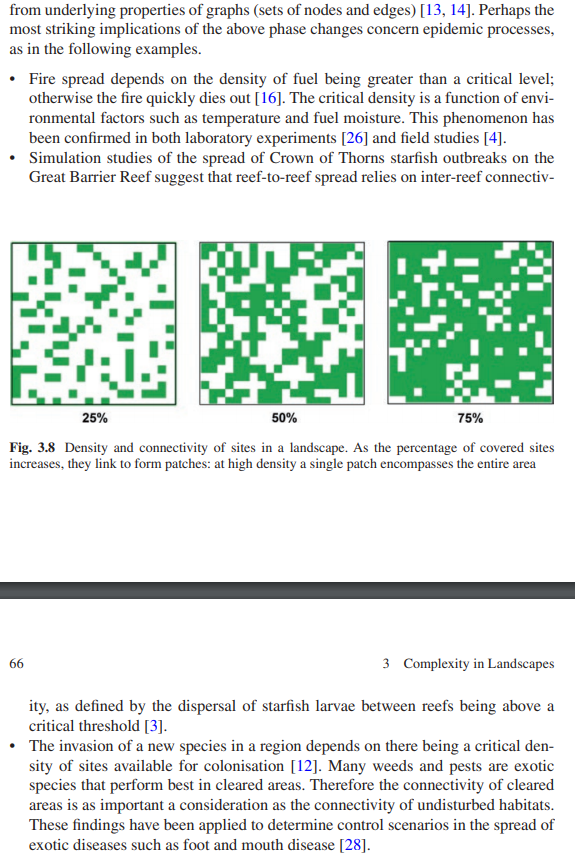

The key result to emerge from studies of connectivity is that landscapes can exist in two different phases: connected and disconnected [14]. The variability that occurs at the phase change means that the size and distribution of landscape patches become highly unpredictable when the density of active regions is at the critical level.

Some birds can fly great distances in the course of a single day. This can lead to landscape connectivity on a grand scale. For instance, David Roshier and his colleagues looked at the connectivity of water bodies in central Australia for the water birds that inhabit them [32]. They did this by assuming that water birds would not normally fly more than about 200 km in the course of a day’s travel while moving from one lake or swamp to another (cf. Chap. 8). On this basis, they found that during wet years the entire continent was effectively connected.

It is important to realise that habitat connectivity will vary from species to species. Just because one species finds a habitat connected does not mean that this is the case for all species.

populations may be fragmented even in the absence of corresponding landscape patterns. Similarly, environmental conditions may change, so populations may have been fragmented in the past.

# Chapter Four: Complex Networks in Ecology

Networks are inherent in all complex systems. Patterns of interactions influence system behaviour. Many kinds of large scale patterns emerge from local interactions, including critical collapse. Ecosystems are really interconnected networks of many kinds, so changed conditions in one network can affect the entire ecosystem.

The whole emerges out of interactions between many individual parts. But just how does that organisation occur? This is the challenge that complexity theory seeks to answer.

Complexity theory concerns phenomena that arise from interactions within large collections of objects

**self-organisation:** Patterns and order in nature arise from two main sources. One source is external constraint. For example, environmental conditions limit the spread of plant and animal populations across a landscape. However, a more subtle source of organisation and order stems from internal interactions and processes.

## The Network Model

### Interactions and Connectivity

A fire spreading through a landscape is like a disease spreading through a population. It is also like an invasion of exotic weeds, an outbreak of starfish, or the spread of a locust plague. They are alike because all of them are examples of epidemic phenomena, in which a process moves from individual to individual (or place to place).

All of these ecological processes bear similarities to well-known physical processes, such as water percolating through porous rock or even a nuclear explosion.

If we are going to understand self-organisation, then first we need to understand the impact of interactions and connections between the parts of the system [15]. The first and most important lesson is that interactions do matter. What is more, interactions at a local scale can produce global effects. A good example is the way in which dispersal (interactions between sites in a landscape) can affect the dynamics of whole ecosystems [12].

**Networks**

the simplest model is a graph. A graph is simply a set of objects, which we call nodes or vertices. Pairs of these nodes are joined by edges.

A graph is called connected if there are paths linking each node to every other node; it is called fully connected if every pair of nodes is connected by an edge. A cluster is a fully connected subgraph. The number of edges linked to a node is called the degree of that node.

**Networks are Everywhere**

spatial processes, such as seed dispersal, make connections between different locations in a landscape. In other words, they create a landscape network. The nodes of this network are sites in the landscape; the edges are processes that link them, such as movement of animals, flow of water, or dispersal of seeds.

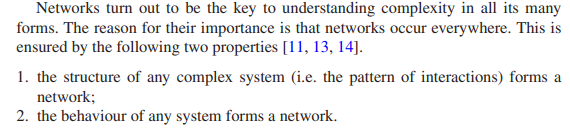

### The Connectivity Avalanche

“what happens if you take a set of nodes and progressively add edges to pairs of nodes chosen at random?” It turns out that at first the set of connected nodes is very small. For the most part, you just get pairs joined together by a single edge. At a certain point in the procedure, a startling change occurs. Suddenly, all the separate pairs and small clusters of nodes start combining together into a large connected network. This process, known as a connectivity avalanche, occurs when the number of edges is approximately half the number of nodes. When the density of edges reaches this critical point, a phase change occurs in the network— from essentially disconnected to almost fully connected.

### Phase changes and Criticality

Criticality is a property that is associated with change in complex systems. The changes involved are often sudden and dramatic. Critical processes often involve predictable changes in structure or properties. Changes of this kind are called phase transitions.

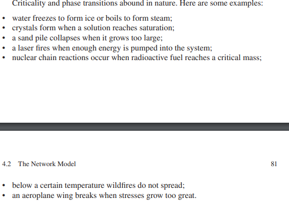

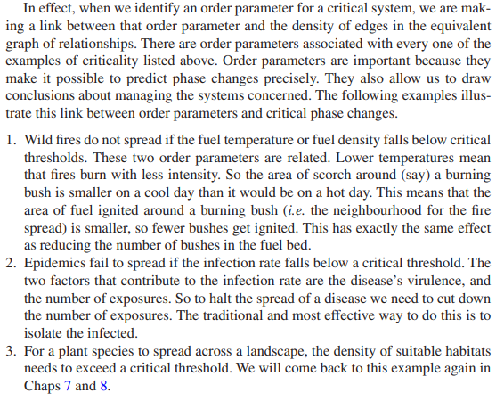

## Self-Organisation

### Emergent Properties

The large-scale behaviour of a system emerges out of the properties and interactions of many individual objects

Three aspects of aggregates of individuals influence the nature of the system that emerges. First, there is the character of the agents themselves. Bees in a swarm behave differently from birds in a flock. The second aspect is the quality of the interactions between the agents. Individuals in a rioting mob interact very differently from guests at a cocktail party. The third aspect is the “wiring pattern” in the network of interactions between agents. The pathways of influence in a feudal kingdom are different from those in a democracy.

An important issue is whether the interactions persist across different scales.

Dissipative systems to explain how some systems can accumulate order. Dissipative systems are open systems that are maintained in an orderly state by exchanging energy with their environment. That is, they take in energy from their environment, use that energy to generate orderly internal structures, and dissipate it to the environment in a less orderly form.

In dissipative systems, there is no tendency to smooth out irregularities and for the system to become homogeneous. Instead, irregularities in dissipative systems can grow and spread.

### Modularity

The solution is to organise large systems into discrete subsystems (modules) and to limit the potential for interactions between the subsystems. This modularity not only reduces the potential for unplanned interactions, but also simplifies system development and maintenance.

Although hierarchies reduce complexity, as described above, they also introduce brittleness into a system. Removing a single node, or cutting a single connection breaks the network into two separate parts. Every node below the break becomes separated from the rest of the system. This brittleness occurs because hierarchies are minimally connected. There is no redundancy in the connections.

Recent studies suggest that instead of hierarchies, many large systems, including metabolic pathways, large societies, and some ecosystems, are organised as scalefree networks.

complex networks pervade our world and offer a powerful way to look at a wide range of processes. Understanding the structures that occur in networks, and how these influence processes within them, can provide insights into the functioning of complex systems.

# Chapter Five: Feedback and Stability in Ecosystems

Ecosystems are dynamic and apparent stability may be an illusion of scale. Some ecosystems are subject to chronic disturbance. In dynamic systems, equilibrium is difficult to achieve and maintain. Systems often exhibit sensitivity to initial conditions and chaotic behaviour. Negative feedback promotes stability. Positive feedback is destabilizing, but also promotes the emergence of large-scale order in complex systems.

people talking about the ‘balance of nature’. This expression reflects a widely-held assumption that balance, or equilibrium, is the natural state of any ecosystem. At best, this assumption is only partly correct. The illusion of equilibrium arises from the long time-scales associated with many ecological phenomena. Just as the lake at sunset looks still and unchanging, it is easy to be fooled into thinking that ecosystems are unchanging because we cannot see them change within our familiar time frame.

The time scale (and occasionally the spatial scale as well) on which things happen is sometimes so large that to a human observer an ecosystem looks still and unchanging.

Studies on these ‘small’ scales can lead to the false impression that the landscape as a whole is in a stable equilibrium. Ecologists now know that the appearance of permanence is often an artefact of the scales at which people operate.

## Feedback

At the simplest level, connections in an ecosystem form chains.

### Negative Feedback Promotes Stability

Negative feedback occurs when activation of one part of a system reduces the activity of the component that activated it. Negative feedback loops result in convergent behaviour. For example, increasing numbers of rabbits might lead to increasing numbers of foxes, which in turn would lead to reducing the numbers of rabbits again.

In controlling any kind of system, negative feedback is desirable because it tends to return a system to its previous state following any perturbation. In theory, negative feedback would stabilise ecological systems. In practice, the response of one population to another often lags, because it takes time to reproduce. This can lead to oscillations in population size, and to a wide variety of non-linear and chaotic behaviour [19].

### Positive Feedback Promotes Self-Organisation

Sometimes, growth rate of a system component increases as its size increases. This is a positive feedback. It results in divergent behaviour. Rolling snowballs downhill, compound interest, growth of a plant seedling and nuclear explosions are all examples of positive feedback.

From the perspective of control, positive feedback is undesirable because it destabilizes a system. In a system where positive feedback operates, any small deviation leads to further deviations, and the deviations grow larger and larger until the entire system collapses.

Paradoxically, this process, which is so destructive when trying to control and maintain the status quo in a complex system, can also act as a constructive process that promotes self-organization and enables order to emerge out of random chaos. This is possible because positive feedback can make a small, local variation grow to become a large, global property

One example of positive feedback contributing to the emergence of order occurs in the connectivity avalanche (Chapter Four). As more edges are added to a graph, connected clumps grow larger. As they grow larger, it becomes increasingly likely that they will become linked to other large clumps, so the rate of growth accelerates.

### The Big get Bigger

In ideal conditions, any population will grow at a rate that is proportional to its present size. Just like compound interest acting on an investment, or a snowball rolling down a hill, the bigger it gets, the faster it grows. It is the result of a positive feedback loop. In mathematics, this kind of behaviour is known as exponential growth

The effect of a limiting resource on exponential population growth is a pattern known as logistic or sigmoidal growth.

The logistic growth model represents exponential reproduction, but with increasing mortality as the population increases. The population increases exponentially at first, while the influence of mortality is very small. As the population increases, however, mortality becomes significant. At a certain population size, growth is balanced by mortality. This maximum population size is termed the carrying capacity.

# Chapter Six: Populations in Landscapes

In fragmented landscapes, species are often found in spatially separated, but interacting metapopulations. The combination of dispersal, competition and environmental variations lead to distribution patterns, especially clumps, patches, boundaries and zones.

## One Population or Many?

This picture of populations being made up of subpopulations leads to the idea of metapopulations. A metapopulation is a ‘population of populations’. It is a mistake to focus on a single subpopulation without considering how it is influenced by other subpopulations in the landscape.

Small populations are sensitive to extinction, and local extinctions are regular events. Survival of a local population depends on the interaction with surrounding populations.

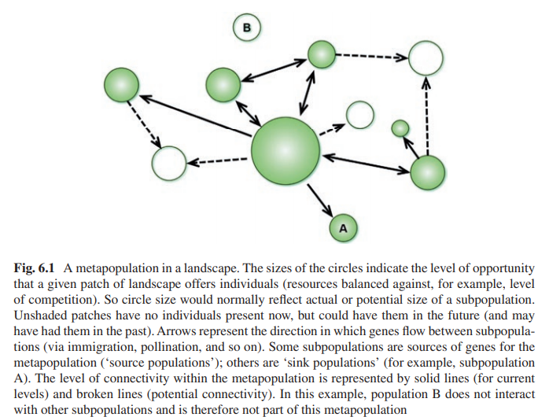

What is important here is how well connected the different patches or islands are. If no individuals move between different patches, then you have a collection of isolated populations. But if isolation is not complete, if the patches do interchange individuals, and if the movement between populations is sufficient to recolonise a patch after the species becomes locally extinct, then, like the butterflies of Åland, regional extinction of the entire group of populations (a metapopulation) becomes unlikely.

The degree of connectivity within a population is intimately related to the rates at which immigration and emigration take place between patches.

## Spatial Distribution

The ways in which organisms are distributed in a landscape can be very complex. The physical environment may also vary. However, spatial processes and interactions also have a big influence on distribution patterns.

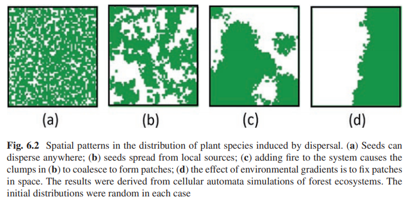

Processes that involve movement across a landscape are responsible for many kinds of patterns in the distribution of vegetation.

## Patches, Edges, and Zones

Research by quantitative ecologists showed that landscape interactions, such as competition and dispersal, play important roles too.

For instance, competition between species often leads to truncated distributions along an environmental gradient. The significance of these findings is that ecosystems are not controlled in simple fashion by external (i.e. abiotic) factors. Internal, biotic interactions within a system play an important role too. These biotic interactions are likely to be nonlinear and complex.

## Galloping Trees?

About 18,000 years ago, most of eastern North America was covered by huge ice sheets, over a kilometre thick in places. As the ice melted, vast areas of land again became ice free. Plants migrated into these regions and forests appeared.

In North America, palynologists used data, compiled from hundreds of individual sites, to reconstruct the northward migration patterns of forest populations as they followed the retreating ice sheets.

These maps portrayed the northward migrations of tree species following the last ice age as a steady, continuous flow. Initially, everyone accepted these migration maps at face value. That is, they assumed that the contours showing arrival times of different plants at different locations should be taken literally [3, 4, 10, 38]. In fact, the entire process was more complex: interactions between different competing populations had an enormous influence on the course of events.

Overall the speeds achieved by migrating trees were typically around 200 metres per year; sometimes they were as high as two kilometres per year. Such speeds may be startling if we restrict our thinking to seeds falling from a tree and settling on the ground nearby, but animals and birds sometimes carry seeds great distances. Storms may be even more important in long distance transport. At first sight, it may seem impossible that wind could pick up a large seed, such as an acorn, and move it anywhere. However, hurricanes at the right time of the year can easily rip entire branches off trees and carry them kilometres in one giant step.

It turns out that populations do not move forward in broad fronts at all. Instead, storms and other means of transport enable small patches of trees to gain a foothold well outside their normal range.

# Chapter Seven: Competition and Stability in Communities

Complexity in landscapes, especially the effect of the connectivity avalanche, influences fundamental ecological processes, such as competition and invasion. Positive and negative feedback play crucial roles in food webs and determine whether complex ecosystems are stable. Structural complexity, including landscape patterns and species mix, is crucial in maintaining the resilience of ecosystems.

This pattern of invasion – suppression followed by explosion – is a direct consequence of the phase change in landscape connectivity.

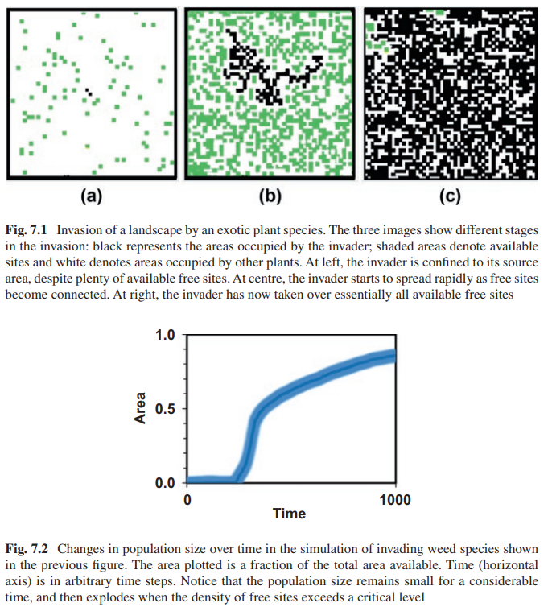

## Resilience

**Resilience:** the capacity of a system to absorb disturbance and reorganize while undergoing change so as to still retain essentially the same function, structure, identity, and feedbacks.

Research into resilience has always been concerned with the interaction between human activities and ecosystems:

*“… ecosystems with self-organized spatial patterns are likely to benefit greatly from conservation and restoration actions that use the emergent effects of self-organisation to increase ecosystem resistance to disturbance.”*

Other studies point to the effects of environmental change. An ALife study of host–parasite networks cast doubt on the resilience of existing networks to global environmental changes [32]. The study found that known networks were robust to historical conditions but fragile when confronted with random changes. Such findings suggest that global environmental changes might lead to the collapse of otherwise robust ecosystems.

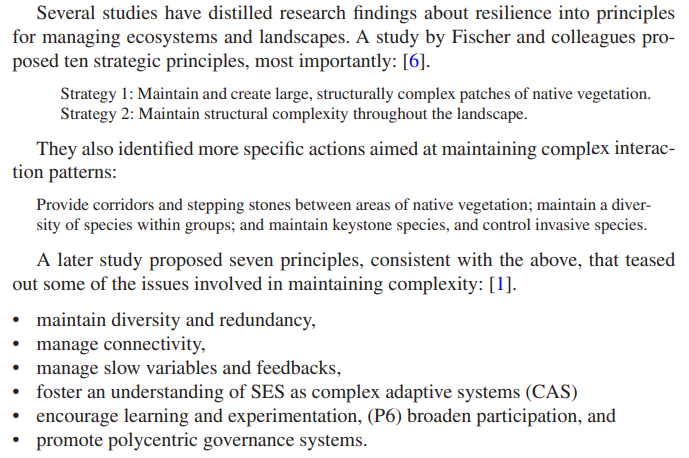

# Chapter Eight: Adaptation in Landscapes

Species adaptation often involves trade-offs between selection for competing needs. Connected landscapes inhibit evolutionary divergence, but heterogeneity, gradients and fragmentation can all create conditions in which evolutionary variation increases. Disturbances create conditions for bursts of diversification by altering landscape connectivity.

# Chapter Nine: The Role of Simulation in Ecology

Unlike empirical researchers, modellers have absolute control over their experimental system, so there is always the danger (intentional or not) of building a system that, rather than challenging our ideas, simply appears to confirm them.

how can we be sure that models truly represent what is going on in real ecosystems? This is the validation problem. Modellers usually resort to simulation when a process or system is so complex that analytic models are intractable. Given that a complex system may be unpredictable, no model is ever going to act precisely like the real thing, so even a valid model may not be capable of prediction. Given this limitation, validation can take several forms. One method is to validate the mechanisms built into a model. For example, we might experimentally determine that the neighbourhood function of a cellular automaton accurately represents the dispersal pattern of a certain species. Another method is to validate the general adequacy of the model for its intended use. For instance, an ecological model might explain how plant distributions form, but not to predict the exact distribution of a species in a real landscape.

The issue of scale has a great bearing on the way we represent a model. Sometimes we may need more than one model to understand the same process at different scales. For example, in developing possible control scenarios for the introduction of foot and mouth disease into Australia, two models were required [24]. A cellular automaton model considered the large scale picture, with probabilities of spread between cells occupied by feral pigs. At a finer scale model, a multi-agent model tested assumptions built into the large-scale model. It incorporated behaviour of individual pigs within an environment and dealt with the problem of rare events: the transmission of disease from one individual to another

# Chapter Ten: New Technologies Are Revolutionizing Ecology

New technologies are helping us to study and understand complexity of ecosystems in detail. Transformative technologies include more sophisticated methods for monitoring (sensors, remote sensing, drones); greater abilities to embrace broadscale phylogeography, and access to the power of e-science (big-data, simulation, visualisation). International repositories now gather data about biodiversity, species distributions and whole ecosystems from around the world.

Genetic Algorithms and Bayesian networks used to cope with ecological information

## Using Machine Learning

Models of plant distribution seek to identify the potential distribution of a species within a landscape by relating its known distribution to climate and other environmental factors.

Complexity poses a challenge for predicting distributions. Inter-species competition often means that populations are not in equilibrium with their environment [65]. The result is a difference between a species’ realized niche and its fundamental niche. The realized niche is the actual role a species plays. We can infer this from its observed environmental distribution. The fundamental niche is the range of roles it could play. The two distributions can be very different, as we see in invasions of exotic species, such as the Cane Toad [24, 64].

# Chapter Eleven: Limits to Growth Versus Growth Without Limits

Environmental changes, whether natural or human-made, trigger complex cascades of consequences. Such cascades played a role in the collapse of past civilisations. Those events provide lessons for current ecological challenges, especially global climate change and loss of biodiversity. The economic imperative for constant growth poses a major challenge for global conservation.

No ecosystem is a closed box. Whether it is a forest, a mountaintop, or a swamp, every ecosystem exists within the larger context of the surrounding region. At first glance, a lake or pond may seem to be isolated from its surroundings, but it is not. It interacts with the outside world.

## The Fall of Civilisations

The sad lesson of history is that most ancient civilisations proved environmentally unsustainable. Many civilisations over-exploited the landscape, so wiping out the natural resources on which their existence depended. These civilisations ultimately suffered the consequences of landscape degradation.

The case of the ancient Sumerians provides a salutary lesson for modern times. Here was a magnificent empire that at its height encompassed many thousands of square miles of territory. The development of their empire forced the ancient Sumerians to consume resources at an unsustainable rate [76]. A major problem was increasing salinity, which increasingly impacted on agriculture [33]. It took about 1000 years for this process to run its course. Although the degradation was constant, it occurred very slowly. Within any single human lifetime, the changes were so small that they were not noticeable. But when the changes began to affect the welfare of the empire, the Sumerians were unable to adapt. At no point, were they able to foresee the dangers and plan accordingly. Their institutions were too rigid to make possible the changes they needed to make in order to survive. In the end their empire was so weakened by famine, disease and shortages of resources that competing empires were able to destroy them so utterly that their very existence was forgotten for thousands of years.